```python
#imports↔
```

```
True
```

# Naive Baysian Sentiment Prediction Revisited

This is an assignment for my thinkful data science course - "naive_bayes_sentiment_prediction_revisitedv2." The goal of the exercise is to iteratively improve the naive baysian model that classifies reviews as positive or negative, and to compare those models, answering three questions:

- Do any of your classifiers seem to overfit?
- Which seem to perform the best? Why?
- Which features seemed to be most impactful to performance?

I'm defining performance as improvement in accuracy over baseline performance when predicting on any of 3 types of review sentence: imdb, amazon, or yelp.

Raj Prasad May 2019

[html version](https://daddyprasad5.github.io/naive_bayes_sentiment_prediction_revisitedv2.html) - with all the code hidden away for a quick read

[jupyter notebook version](https://github.com/daddyprasad5/thinkful/blob/master/naive_bayes_sentiment_prediction_revisitedv2.ipynb) - with all the code exposed in an interactive notebook

1. A model trained on the **imdb data only** and built with **hand-selected one-hot features** indicating presence or absence of a lemma in the review sentence.
2. A model trained on the **imdb data only** and built with **algorithmically-chosen, one-hot features** indicating presence or absence of a lemma in the review sentence. These features are chosen based on both high occurrence and high sentiment-splitting.
3. Trained with **hand-chosen features** from **all 3 review types** and trained on all 3 types of review (imdb, amazon, and yelp).
4. Trained with **algorithmically-chosen features** from **all 3 review types** and trained on all 3 types of review.
5. Same as the fourth model, but also including "review type" as a feature, where review type is either imdb or not (has to be a binary variable to use the bernouli distribution).
6. Trained with all the features - hand-selected, algorithmically-chosen and the review type- and trained on all 3 types of review.

To answer the questions posed:

**Do any of your classifiers seem to overfit?**

No. The leave one out showed some pretty tight distribution of accuracies across trials.

**Which features seemed to be most impactful to performance?**

The occurence rate of a feature was very important to it's classifying power. That's intuitive - i.e. it doesn't help if a lemma's presence always indicates positive sentiment if it only shows up in .001% of the sentences. Another way to say this is that the variance of the feature is important to it's classifying power. If it's always one-value or another, that's not very helpful.

The models all seem to be biased to guessing negative, despite there being no class bias in the population. This problem might benefit from using logistic regression or SVM, so a higher bar for guessing negative could be set.

```python
# Grab and process the raw data.↔
```

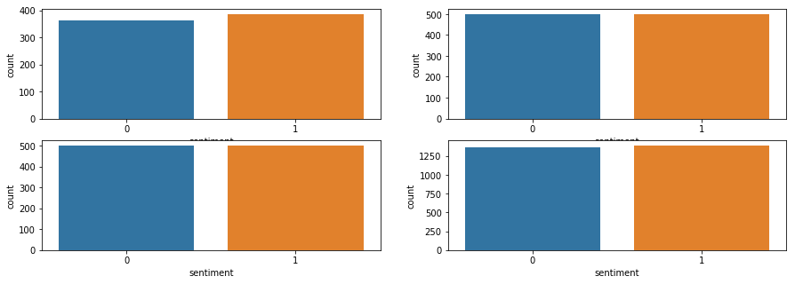

```
The dominant class rate for all reviews is  0.5043668122270742
That's the accuracy rate we'd get if we always guessed 'positive'
```

```python
#peak at the distributions of the three datasets and the combined dataset. ↔
```

There is no material class imbalance. Any accuracy over 50.4% is an improvement.

```python
#add a column of the lemmas in each sentence, and calculate the occurrence rate of each lemma↔
```

```python
#define hand-selected features for model 1 and model 3↔
```

```python
#define algorithmically-selected features for models 2, 4, and 5↔
```

```python
#print the features for each model, for reference↔
```

```
['bad', 'good', 'like', 'great', 'well', 'best', 'love', 'funny', 'better', 'wonderful']
['awful' 'suck' 'interesting' 'worst' 'wonderful' 'stupid' 'waste'
 'nothing' 'bad' 'played' 'loved' 'liked' 'im' 'hour' 'give' 'would'
 'excellent' 'job' 'art' 'funny']
['good', 'great', 'like', 'bad', 'well', 'best', 'love', 'better', 'nice', 'recommend']
['interesting' 'worst' 'waste' 'wonderful' 'loved' 'awful' 'great' 'bad'
 'excellent' 'stupid' 'terrible' 'nothing' 'suck' 'played' 'beautiful'
 'love' 'minute' 'enjoyed' 'liked' 'funny']
['interesting', 'worst', 'waste', 'wonderful', 'loved', 'awful', 'great', 'bad', 'excellent', 'stupid', 'terrible', 'nothing', 'suck', 'played', 'beautiful', 'love', 'minute', 'enjoyed', 'liked', 'funny', 'review_type']
{'terrible', 'suck', 'recommend', 'liked', 'loved', 'excellent', 'wonderful', 'nothing', 'like', 'minute', 'art', 'enjoyed', 'beautiful', 'im', 'played', 'job', 'good', 'would', 'give', 'interesting', 'funny', 'awful', 'worst', 'love', 'great', 'better', 'waste', 'review_type', 'nice', 'bad', 'stupi…
```

```python
#add the feature columns to each datasets↔
```

```python
#train the models and evaluate on the training data↔
```

```
model 1 on training data error rate is  0.39572192513368987
model 2 on training data error rate is  0.34759358288770054
model 3 on training data error rate is  0.3511644832605531
model 4 on training data error rate is  0.37554585152838427
model 5 on training data error rate is  0.37554585152838427
model 6 on training data error rate is  0.3016739446870451
```

When testing on the training data...

- the hand-picked features (models 1 & 3) outperformed the algorithmically generated features on the full dataset, but not on the imdb-only dataset.
- the review_type feature addition (model 5 vs. model 4) did not impact performance.

```python
#test the models with holdout data↔
```

```
model 3 accuracies:  [0.58695652 0.60144928 0.60727273 0.74545455 0.68       0.70545455
 0.6350365  0.64963504 0.62773723 0.64963504]
model 3 ave acc:  0.6488631410903706


model 4 accuracies:  [0.61956522 0.65942029 0.64       0.68363636 0.62181818 0.6
 0.59854015 0.60948905 0.60218978 0.61313869]
model 4 ave acc:  0.62477977169345


model 5 accuracies:  [0.61956522 0.64130435 0.64       0.68363636 0.62181818 0.6
 0.59854015 0.60948905 0.60218978 0.61313869]
model 5 ave acc:  0.6229681774905513
model 6 accuracies:  [0.69202899 0.6884058  0.72       0.77090909 0.70545455 0.71272727
 0.65693431 0.68248175 0.65693431 0.66788321]
model 6 ave acc:  0.695375926834194
```

The hand-picked features outperform the algorithmically selected features.  
Review Type as a feature has no impact - which is suprising.

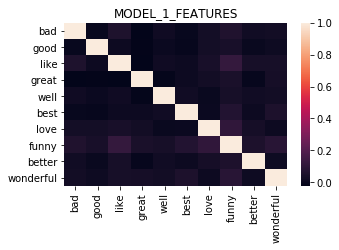

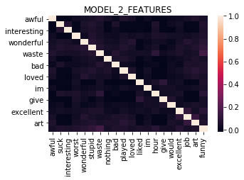

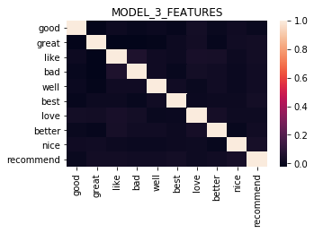

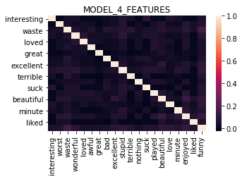

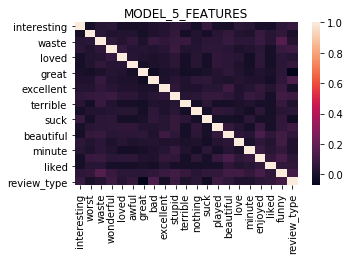

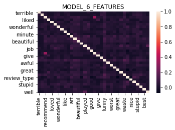

```python
#test for correlation between feature pairs
#looks pretty good (i.e. low pair-wise correlation for all feature sets)
feature_sets = [MODEL_1_FEATURES, MODEL_2_FEATURES, MODEL_3_FEATURES, MODEL_4_FEATURES,
                MODEL_5_FEATURES, MODEL_6_FEATURES]
titles = ["MODEL_1_FEATURES", "MODEL_2_FEATURES", "MODEL_3_FEATURES", "MODEL_4_FEATURES",
                "MODEL_5_FEATURES", "MODEL_6_FEATURES"]
i=0
for feature_set in feature_sets:
    plt.figure(figsize=(5, 3))
    ax = plt.axes()
    corrs = reviews_raw[feature_set].corr()
    sns.heatmap(corrs)
    ax.set_title(titles[i])
    i+=1
    plt.show()
```

```python
#different error types - confusion matrix↔
```

```
Model 3 confusion matrix...
[[1253  109]
 [ 856  530]]
Model 4 confusion matrix...
[[1345   17]
 [1015  371]]
Model 5 confusion matrix...
[[1345   17]
 [1015  371]]
Model 6 confusion matrix...
[[1253  109]
 [ 720  666]]
```

All the models are guessing negative much more often than positive, and the high false negative rate reflects that.